# Basic statistic: Mean, Median, Mode

## Mean

- `mean` is het gemiddelde van een aantal gegevens (numerical, discrete)

**Voorbeeld** Het aantal kinderen per huis in de buurt: 0, 2, 3, 2, 1, 0, 0, 2, 0

Mean: (0+2+3+2+1+0+0+2+0) / 9 = 1.11

## Median

- `median` is de waarde van het middelste getal in de (numeriek)gesorteerde gegevens

**Voorbeeld** Het aantal kinderen per huis in de buurt: 0, 2, 3, 2, 1, 0, 0, 2, 0

**Median**

- originele reeks: 0,2,3,2,1,0,0,2,0
- gesorteerde reeks: 0,0,0,0,1,2,2,2,3
- median: 1 (middelste waarde)

NB. Bij een *even* aantal getallen: median is gemiddelde van de middelste getallen

## Mode

- `mode` is de meest voorkomende waarde in de dataset.
  > - niet relevant voor continu numerieke gegevens

**Voorbeeld** Het aantal kinderen per huis in de buurt: 0, 2, 3, 2, 1, 0, 0, 2, 0

**Mode**

- hoeveel keer komt elke waarde voor: 0: 4, 1:1, 2: 3, 3:1
- mode: 0

## Mean vs. Median

Let's create some fake income data, centered around 27,000 with a normal distribution and standard deviation of 15,000, with 10,000 data points. (We'll discuss those terms more later, if you're not familiar with them.)

Then, compute the mean (average) - it should be close to 27,000:

```python
import numpy as np

incomes = np.random.normal(27000, 15000, 10000)
np.mean(incomes)
```

```
27055.00954104847
```

We can segment the income data into 50 buckets, and plot it as a histogram:

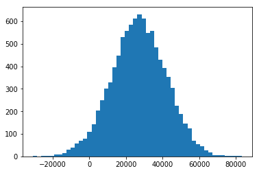

```python
%matplotlib inline
import matplotlib.pyplot as plt
plt.hist(incomes, 50)
plt.show()
```

Now compute the median - since we have a nice, even distribution it too should be close to 27,000:

```python
np.median(incomes)
```

```
27096.935480107095
```

Now we'll add Donald Trump into the mix. Darn income inequality!

```python
incomes = np.append(incomes, [1000000000])
```

The median won't change much, but the mean does:

```python
np.median(incomes)
```

```
27097.77004846769
```

```python
np.mean(incomes)
```

```
127042.3053105174
```

## Mode

Next, let's generate some fake age data for 500 people:

```python
ages = np.random.randint(18, high=90, size=500)
ages
```

```
array([48, 23, 87, 36, 84, 86, 18, 75, 44, 78, 28, 45, 24, 82, 59, 44, 83,
       43, 84, 87, 51, 38, 74, 82, 38, 46, 73, 56, 19, 86, 38, 73, 58, 28,
       27, 46, 31, 76, 76, 52, 77, 28, 24, 72, 82, 74, 89, 89, 62, 20, 60,
       48, 74, 35, 66, 40, 84, 76, 48, 62, 50, 48, 76, 36, 72, 86, 63, 47,
       18, 46, 71, 37, 32, 57, 31, 69, 20, 46, 45, 58, 80, 70, 67, 28, 46,
       74, 69, 38, 83, 81, 82, 45, 24, 20, 18, 43, 44, 87, 58, 62, 64, 51,
       22, 51, 71, 54, 43, 43, 81, 67, 75, 50, 29, 87, 28, 49, 59, 50, 24,
       71, 38, 19, 38, 66, 67, 61, 62, 22, 27, 23, 53, 85, 31, 88, 40, 74,
       25, 31, 50, 25, 34, 29, 31, 29, 82, 24, 40, 85, 62, 36, 32, 24, 47,
       63, 59, 89, 52, 89, 84, 20, 89, 76, 59, 76, 77, 24, 23, 62, 88, 69,
       28, 76, 53, 34, 79, 32, 87, 20, 52, 42, 55, 87, 46, 81, 27, 32, 53,
       61, 60, 78, 74, 55, 48, 66, 23, 38, 48, 33, 35, 53, 52, 57, 21, 20,
       89, 43, 24, 29, 43, 32, 60, 25, 32, 81, 53, 34, 21, 54, 88, 67, 25,
       22, 63, 25, 33, 60, 29, 89, 85, 78, 87, 77, 88, 28, 64, 54, 43, 68,
       19, 19, 27, 19, 37, 36, 65, 53, 81, 48, 76, 71, 68, 74, 80, 63, 34,
       29, 34, 76, 61, 41, 65, 82, 67, 39, 47, 18, 76, 20, 77, 41, 19, 39,
       42, 40, 88, 68, 48, 35, 37, 64, 78, 55, 37, 37, 69, 47, 30, 47, 49,
       53, 82, 47, 27, 36, 35, 65, 25, 25, 27, 57, 29, 84, 48, 39, 80, 62,
       82, 68, 48, 24, 37, 57, 30, 63, 88, 30, 89, 20, 89, 52, 76, 72, 45,
       57, 43, 80, 54, 59, 27, 69, 86, 72, 49, 88, 71, 55, 18, 25, 26, 54,
       31, 77, 62, 29, 26, 81, 57, 88, 29, 84, 70, 58, 60, 55, 33, 60, 34,
       64, 38, 40, 35, 76, 45, 41, 81, 51, 22, 55, 79, 28, 60, 52, 69, 70,
       87, 24, 76, 43, 29, 20, 32, 76, 51, 27, 57, 76, 34, 26, 19, 26, 21,
       81, 71, 70, 60, 56, 34, 59, 26, 83, 35, 83, 83, 58, 21, 59, 67, 44,
       52, 67, 21, 44, 79, 59, 69, 22, 78, 23, 29, 81, 85, 64, 28, 42, 75,
       65, 79, 68, 48, 65, 66, 30, 61, 65, 62, 89, 35, 73, 33, 38, 58, 42,
       24, 42, 65, 44, 39, 36, 32, 32, 58, 69, 20, 22, 59, 87, 38, 21, 87,
       81, 25, 20, 83, 71, 47, 87, 32, 65, 78, 20, 47, 53, 71, 77, 27, 74,
       71, 80, 62, 69, 35, 66, 85, 47, 60, 82, 83, 79, 54, 24, 65, 69, 43,
       63, 57, 56, 71, 23, 81, 59])
```

```python
from scipy import stats
stats.mode(ages)
```

```
ModeResult(mode=array([76]), count=array([15]))
```

`mode`: number `n` is most common value, occurs number `count` times.

## Activity

Zie notebook Exercises - Mean & Median Customer Spend